# Results of longitudinal BOLD delay manuscript

Ahmed Khalil

July 29, 2018

This is a comprehensive report of all the results of the “Longitudinal BOLD delay” manuscript, submitted (major revisions) to *JCBFM* in July 2018. Code written by Ahmed A Khalil (ahmed-abdelrahim.khalil@charite.de).

NB: These are all the results and plots *reported in the manuscript & supplementary material & uploaded to the online repository*.

# 1 Demographics & clinical characteristics

Table 1

| Patient no. | Age (years) | Sex | NIHSS - admission | NIHSS - discharge | Time from symptom onset to MRI (hours) | Occluded vessel | IV thrombolysis | Recanalization | TIMI score | mRS (discharge) | Barthel index (discharge) |
| --- | --- | --- | --- | --- | --- | --- | --- | --- | --- | --- | --- |
| 1 | 78 | M | 3 | 1 | 3.0 | P2 | YES | NO | 0 | 3 | 90 |
| 2 | 74 | F | 3 | 1 | 16.3 | A1 | NO | NO | 0 | 1 | 100 |
| 3 | 36 | M | 6 | 1 | 16.0 | M2 | YES | NO | 0 | 1 | 100 |
| 4 | 67 | M | 19 | 8 | 24.0 | M1 | NO | YES | 2 | 3 | 50 |
| 5 | 79 | F | 4 | 4 | 2.0 | M1 | YES | NO | 0 | 2 | 70 |
| 6 | 78 | M | 1 | 1 | 8.0 | M2 | NO | NO | 0 | 1 | 100 |
| 7 | 88 | M | 2 | 2 | 2.5 | P2 | YES | YES | 3 | 1 | 100 |
| 8 | 75 | F | 14 | 9 | 18.0 | M1 | NO | NO | 1 | 4 | 15 |
| 9 | 49 | F | 3 | 2 | 2.5 | P3 | YES | YES | 2 | 2 | 90 |
| 10 | 77 | M | 0 | 0 | 11.0 | P3 | NO | NO | 0 | 0 | 100 |
| 11 | 47 | M | 11 | 0 | 2.0 | M3 | YES | YES | 3 | 0 | 100 |
| 12 | 66 | M | 9 | 0 | 1.5 | M2 | YES | YES | 3 | 0 | 100 |
| 13 | 81 | F | 19 | 6 | 1.0 | M3 | YES | YES | 3 | 2 | 90 |
| 14 | 56 | M | 3 | 1 | 21.0 | M2 | NO | NO | 0 | 0 | 100 |
| 15 | 74 | M | 11 | 5 | 1.0 | P1 | YES | NO | 1 | 3 | 80 |

```
## [1] "Recanalizers"
```

```
##       Age        Sex     NIHSS_adm      NIHSS_dis       TOO_h
##  Min.   :47.00   F:2   Min.   : 2.0   Min.   :0.0   Min.   : 1.000
##  1st Qu.:53.25   M:4   1st Qu.: 4.5   1st Qu.:0.5   1st Qu.: 1.625
##  Median :66.50         Median :10.0   Median :2.0   Median : 2.250
##  Mean   :66.33         Mean   :10.5   Mean   :3.0   Mean   : 5.583
##  3rd Qu.:77.50         3rd Qu.:17.0   3rd Qu.:5.0   3rd Qu.: 2.500
##  Max.   :88.00         Max.   :19.0   Max.   :8.0   Max.   :24.000
##
##  Vessel Thrombolysis Recanalization      TIMI            mRS
##  A1:0   NO :1        NO :0          Min.   :2.000   Min.   :0.000
##  M1:1   YES:5        YES:6          1st Qu.:2.250   1st Qu.:0.250
##  M2:1                               Median :3.000   Median :1.500
##  M3:2                               Mean   :2.667   Mean   :1.333
##  P1:0                               3rd Qu.:3.000   3rd Qu.:2.000
##  P2:1                               Max.   :3.000   Max.   :3.000
##  P3:1
##     Barthel
##  Min.   : 50.00
##  1st Qu.: 90.00
##  Median : 95.00
##  Mean   : 88.33
##  3rd Qu.:100.00
##  Max.   :100.00
##
```

```
## [1] "Non-recanalizers"
```

```
##       Age        Sex     NIHSS_adm    NIHSS_dis         TOO_h      Vessel
##  Min.   :36.00   F:3   Min.   : 0   Min.   :0.000   Min.   : 1.0   A1:1
##  1st Qu.:74.00   M:6   1st Qu.: 3   1st Qu.:1.000   1st Qu.: 3.0   M1:2
##  Median :75.00         Median : 3   Median :1.000   Median :11.0   M2:3
##  Mean   :69.67         Mean   : 5   Mean   :2.556   Mean   :10.7   M3:0
##  3rd Qu.:78.00         3rd Qu.: 6   3rd Qu.:4.000   3rd Qu.:16.3   P1:1
##  Max.   :79.00         Max.   :14   Max.   :9.000   Max.   :21.0   P2:1
##                                                                    P3:1
##  Thrombolysis Recanalization      TIMI             mRS
##  NO :5        NO :9          Min.   :0.0000   Min.   :0.000
##  YES:4        YES:0          1st Qu.:0.0000   1st Qu.:1.000
##                              Median :0.0000   Median :1.000
##                              Mean   :0.2222   Mean   :1.667
##                              3rd Qu.:0.0000   3rd Qu.:3.000
##                              Max.   :1.0000   Max.   :4.000
##
##     Barthel
##  Min.   : 15.00
##  1st Qu.: 80.00
##  Median :100.00
##  Mean   : 83.89
##  3rd Qu.:100.00
##  Max.   :100.00
##
```

# 2 Volumetric analysis

## 2.1 Figure 1 - Volume Boxplots with points overlain (manual delineation)

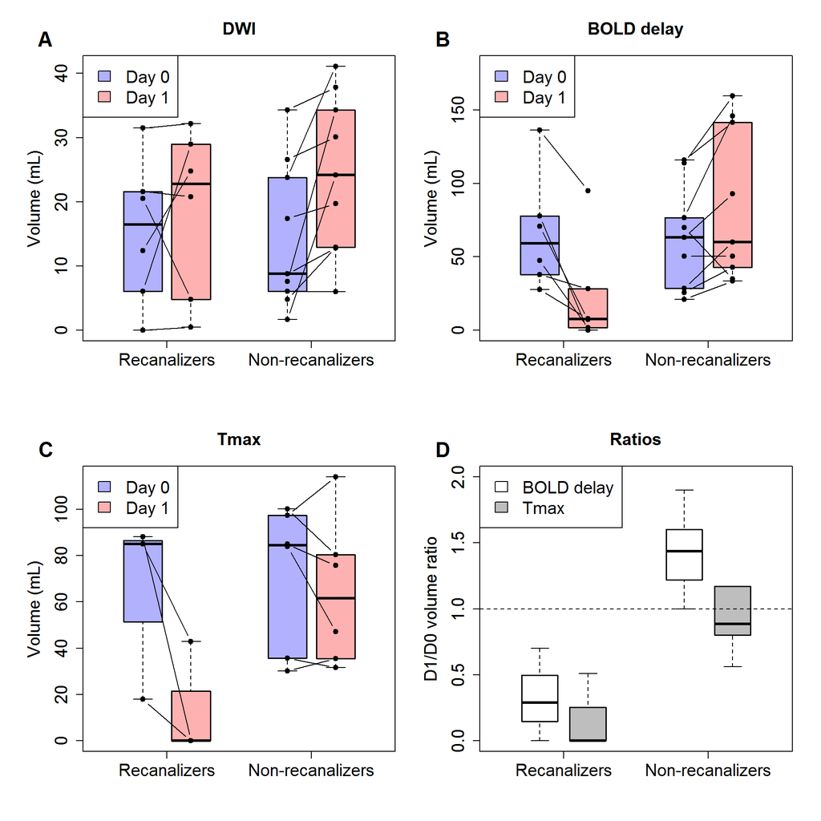

*Note that for the first 2 subfigures (A-B), ALL patients in the sample are included. For the last 2 subfigures (C-D), only patients who had both BD and Tmax are included.*

## 2.2 Supp Figure 1 - Volume Boxplots (automated delineation)

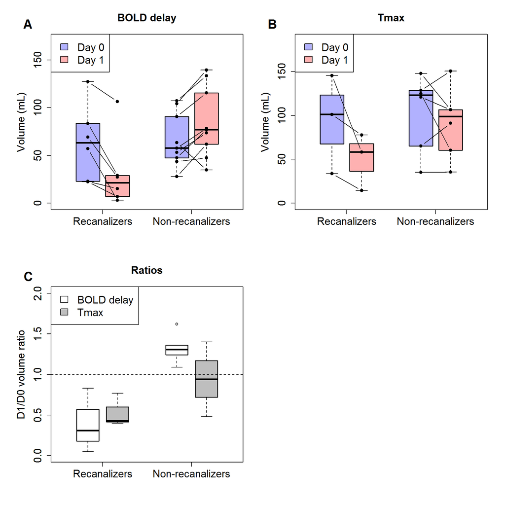

## 2.3 Lesion growth in recanalizers vs non-recanalizers

Difference between DWI lesion growth in recanalizers (median=1.02, IQR=0.96–2) vs non-recanalizers (median=1.46, IQR=1.13–2.71), p=0.3501179

Difference between BOLD delay lesion growth (manual) in recanalizers (median=0.195, IQR=0.055–0.5975) vs non-recanalizers (median=1.47, IQR=1.22–1.67), p=0.0015984

Difference between BOLD delay lesion growth (auto) in recanalizers (median=0.37, IQR=0.32–0.6) vs non-recanalizers (median=1.34, IQR=1.24–1.38), p=0.0015984

**In patients with vessel recanalization within 24 hours of baseline imaging, BOLD delay lesions become smaller. In patients with persistent vessel occlusion (PVO), BOLD delay lesions expand, unlike Tmax lesions, which tend to remain stable/shrink a little in this situation.**

## 2.4 Correlation between volume ratios and TIMI scores

```
##
##  Spearman's rank correlation rho
##
## data:  volumes_data$TSA_ratio_man and demo_allsubs$mRS
## S = 336.34, p-value = 0.1402
## alternative hypothesis: true rho is not equal to 0
## sample estimates:
##       rho
## 0.3993987
```

```
##
##  Spearman's rank correlation rho
##
## data:  volumes_data$TSA_ratio_auto and demo_allsubs$mRS
## S = 359.93, p-value = 0.1911
## alternative hypothesis: true rho is not equal to 0
## sample estimates:
##       rho
## 0.3572603
```

Spearman’s rank correlation rho between BOLD delay volume ratio (manual) and TIMI score is -0.72, p = 0.00266.

Spearman’s rank correlation rho between BOLD delay volume ratio (auto) and TIMI score is -0.7, p = 0.00372.

**The change in BOLD delay lesion volume between baseline (D0) and follow-up (D1) correlates with the degree of vessel recanalization as measured by the TIMI score.**

## 2.5 Agreement between manually and automatically delineated perfusion lesion volumes

```
## [1] "BOLD delay ratios manual vs auto"
## [1] "ICC= 0.89 , 95% CI = 0.71 - 0.96 , p = 0 , F = 16.32"
## [1] "Tmax ratios manual vs auto"
## [1] "ICC= 0.7 , 95% CI = 0.18 - 0.92 , p = 0.0072 , F = 6.22"
```

# 3 Relationship between BOLD delay and Tmax - correlation and spatial overlap

```
## [1] "Descriptive stats for BD/Tmax Spearman's correlation (rho) - D0"
```

```
## [1] "All patients, Quantiles ="
```

```
##    0%   25%   50%   75%  100%
## 0.071 0.260 0.430 0.550 0.630
```

```
## [1] "rho_d0_recan Quantiles ="
##    0%   25%   50%   75%  100%
## 0.071 0.309 0.546 0.574 0.601
## [1] "rho_d0_nonrecan Quantiles ="
##    0%   25%   50%   75%  100%
## 0.086 0.276 0.376 0.505 0.634
```

```
## [1] "Descriptive stats for BD/Tmax spatial overlap (Dice coefficient) - D0"
```

```
##    Min. 1st Qu.  Median    Mean 3rd Qu.    Max.
##    0.28    0.44    0.58    0.53    0.63    0.73
```

# 4 Changes in perfusion (BOLD delay/Tmax) over time - group level

## 4.1 Figure 4 - Changes in mean Tmax and BOLD delay values within ROIs in the affected vascular territory

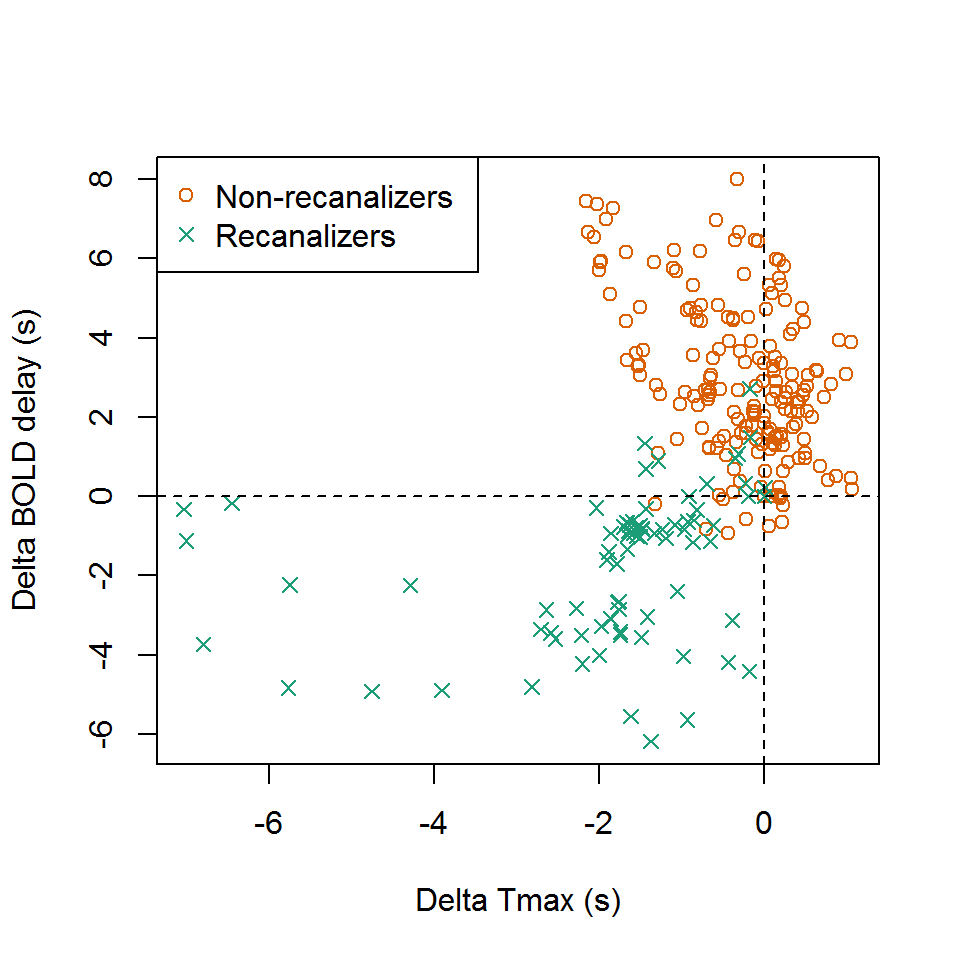

*Note that this is shown for ROIs within the affected VT and only patients who had both BD and Tmax are included.*

## 4.2 Figure 5 - voxelwise changes in BOLD delay and Tmax in subsample with both scans

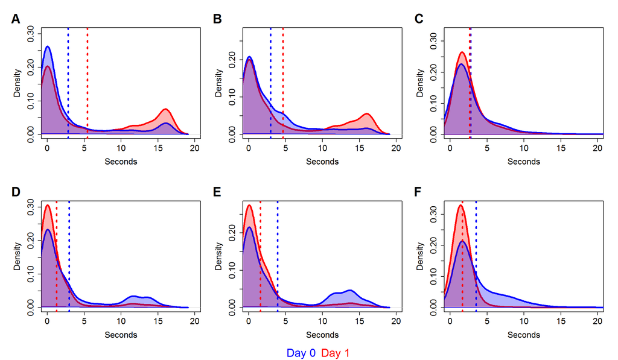

## 4.3 Supp Figure 3 - voxelwise changes in BOLD delay values in entire sample

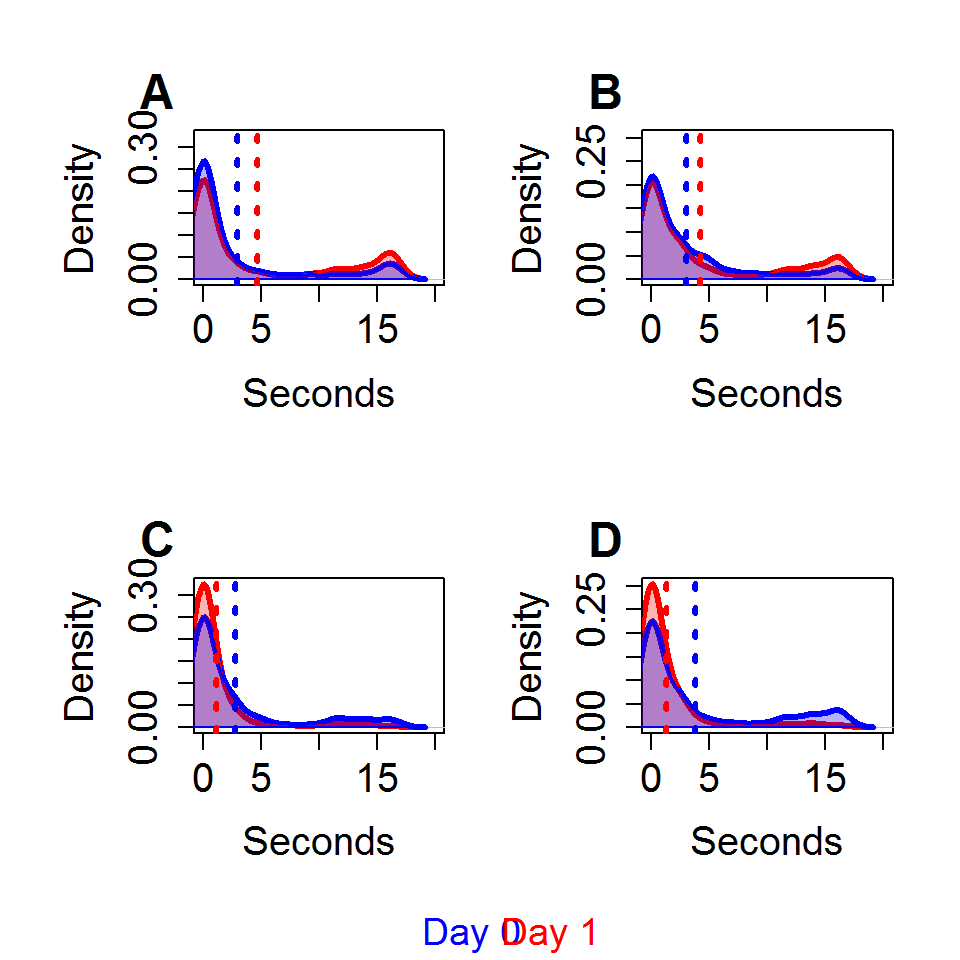

## 4.4 Figure 6 - Mixed models

```
## Type III Analysis of Variance Table with Satterthwaite's method
##             Sum Sq Mean Sq NumDF  DenDF F value    Pr(>F)
## Days          0.51    0.51     1 13.804  0.0069 0.9349140
## Recan       123.99  123.99     1 11.988  1.6969 0.2171677
## Days:Recan 1647.27 1647.27     1 13.804 22.5435 0.0003237 ***
## ---
## Signif. codes:  0 '***' 0.001 '**' 0.01 '*' 0.05 '.' 0.1 ' ' 1
```

```
## Type III Analysis of Variance Table with Satterthwaite's method
##            Sum Sq Mean Sq NumDF  DenDF F value  Pr(>F)
## Days         1.32    1.32     1 13.198  0.0179 0.89547
## Recan        3.66    3.66     1 10.087  0.0497 0.82799
## Days:Recan 379.97  379.97     1 13.198  5.1686 0.04033 *
## ---
## Signif. codes:  0 '***' 0.001 '**' 0.01 '*' 0.05 '.' 0.1 ' ' 1
```

```
## Linear mixed model fit by REML. t-tests use Satterthwaite's method [
## lmerModLmerTest]
## Formula: BDvals ~ Days * Recan + (Recan + Days | Subject)
##    Data:
## BD_vals_allsubs[BD_vals_allsubs$REFs == "VS" & BD_vals_allsubs$ROIs ==
##     "D1IG", ]
##
## REML criterion at convergence: 165123
##
## Scaled residuals:
##     Min      1Q  Median      3Q     Max
## -2.8714 -0.6630  0.2144  0.7247  2.5149
##
## Random effects:
##  Groups   Name        Variance Std.Dev. Corr
##  Subject  (Intercept) 17.852   4.225
##           RecanYes     4.296   2.073    -0.59
##           DaysD1      11.353   3.369    -0.73  0.52
##  Residual             73.071   8.548
## Number of obs: 23146, groups:  Subject, 15
##
## Fixed effects:
##                 Estimate Std. Error     df t value Pr(>|t|)
## (Intercept)        1.695      1.420 10.959   1.194 0.257723
## DaysD1             4.295      1.150 13.202   3.735 0.002435 **
## RecanYes           2.292      2.022  7.514   1.133 0.291945
## DaysD1:RecanYes   -8.742      1.841 13.804  -4.748 0.000324 ***
## ---
## Signif. codes:  0 '***' 0.001 '**' 0.01 '*' 0.05 '.' 0.1 ' ' 1
##
## Correlation of Fixed Effects:
##             (Intr) DaysD1 RecnYs
## DaysD1      -0.723
## RecanYes    -0.702  0.508
## DysD1:RcnYs  0.452 -0.624 -0.642
```

```
## Linear mixed model fit by REML. t-tests use Satterthwaite's method [
## lmerModLmerTest]
## Formula: BDvals ~ Days * Recan + (Recan + Days | Subject)
##    Data:
## BD_vals_allsubs[BD_vals_allsubs$REFs == "HH" & BD_vals_allsubs$ROIs ==
##     "D1IG", ]
##
## REML criterion at convergence: 165284.9
##
## Scaled residuals:
##     Min      1Q  Median      3Q     Max
## -3.1969 -0.7880  0.2020  0.6714  2.5067
##
## Random effects:
##  Groups   Name        Variance Std.Dev. Corr
##  Subject  (Intercept) 33.05    5.749
##           RecanYes    21.43    4.630    -0.35
##           DaysD1      25.19    5.019    -0.50 -0.36
##  Residual             73.52    8.574
## Number of obs: 23146, groups:  Subject, 15
##
## Fixed effects:
##                 Estimate Std. Error     df t value Pr(>|t|)
## (Intercept)        1.462      1.925  8.944   0.760   0.4671
## DaysD1             3.240      1.692 12.899   1.915   0.0779 .
## RecanYes           2.510      3.126  8.600   0.803   0.4437
## DaysD1:RecanYes   -6.120      2.692 13.198  -2.273   0.0403 *
## ---
## Signif. codes:  0 '***' 0.001 '**' 0.01 '*' 0.05 '.' 0.1 ' ' 1
##
## Correlation of Fixed Effects:
##             (Intr) DaysD1 RecnYs
## DaysD1      -0.499
## RecanYes    -0.616  0.307
## DysD1:RcnYs  0.314 -0.629 -0.654
```

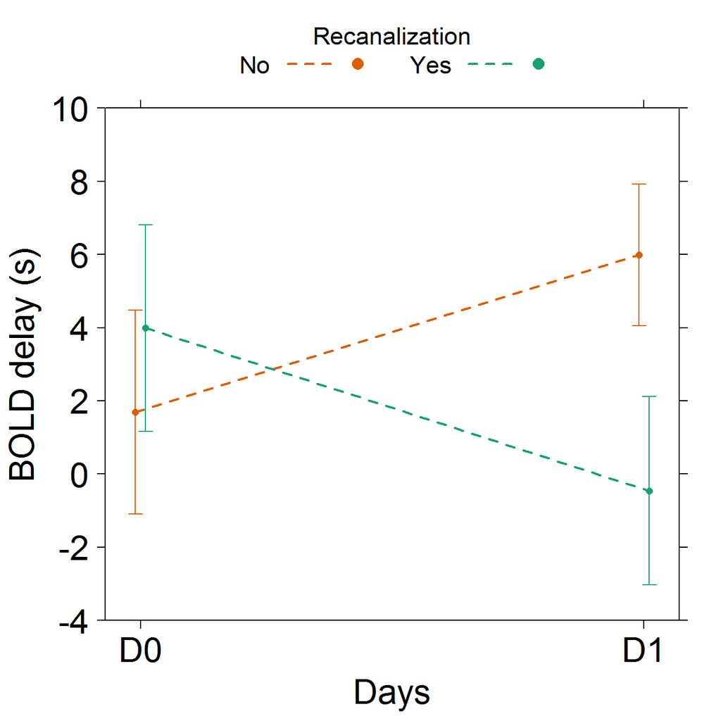

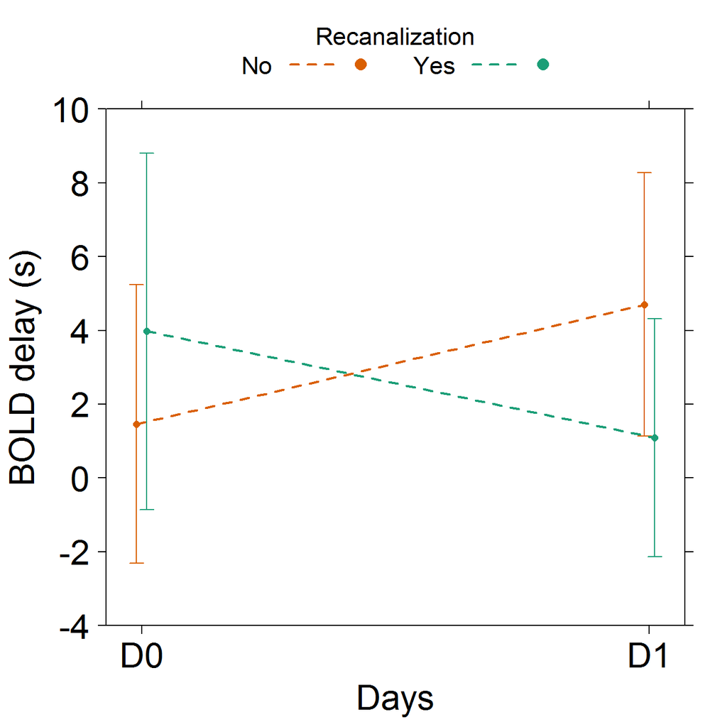

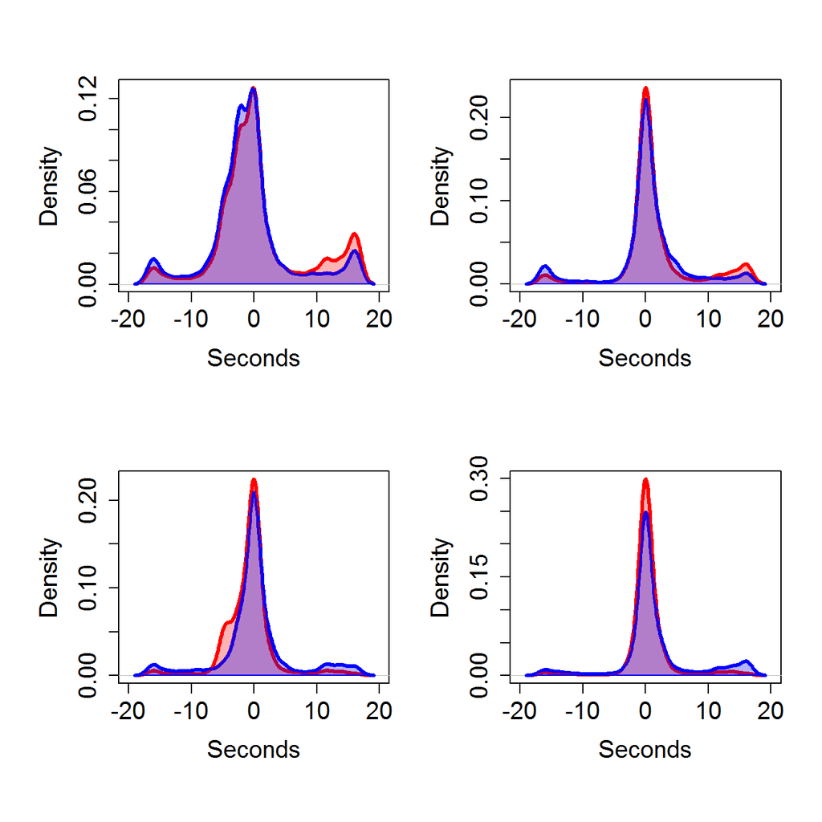

## 4.5 Supp Figure 6 - Distribution of maximum correlation coefficients in ROIs, pooled across all subjects

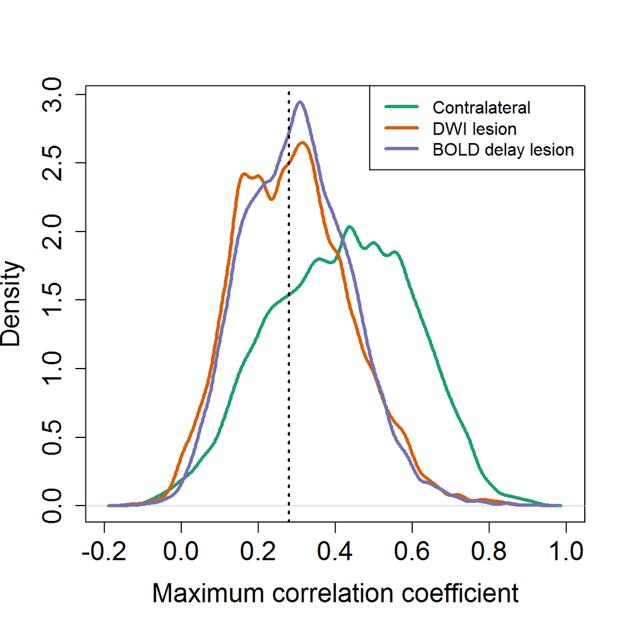

*Note that, in this analysis, n=14 because one subject (sub0179) had a total mismatch at baseline.*

# 5 Changes in perfusion (BOLD delay/Tmax) over time - individual level

These results are not in the manuscript, they are on a publicly accessible repository: https://doi.org/10.6084/m9.figshare.5904619

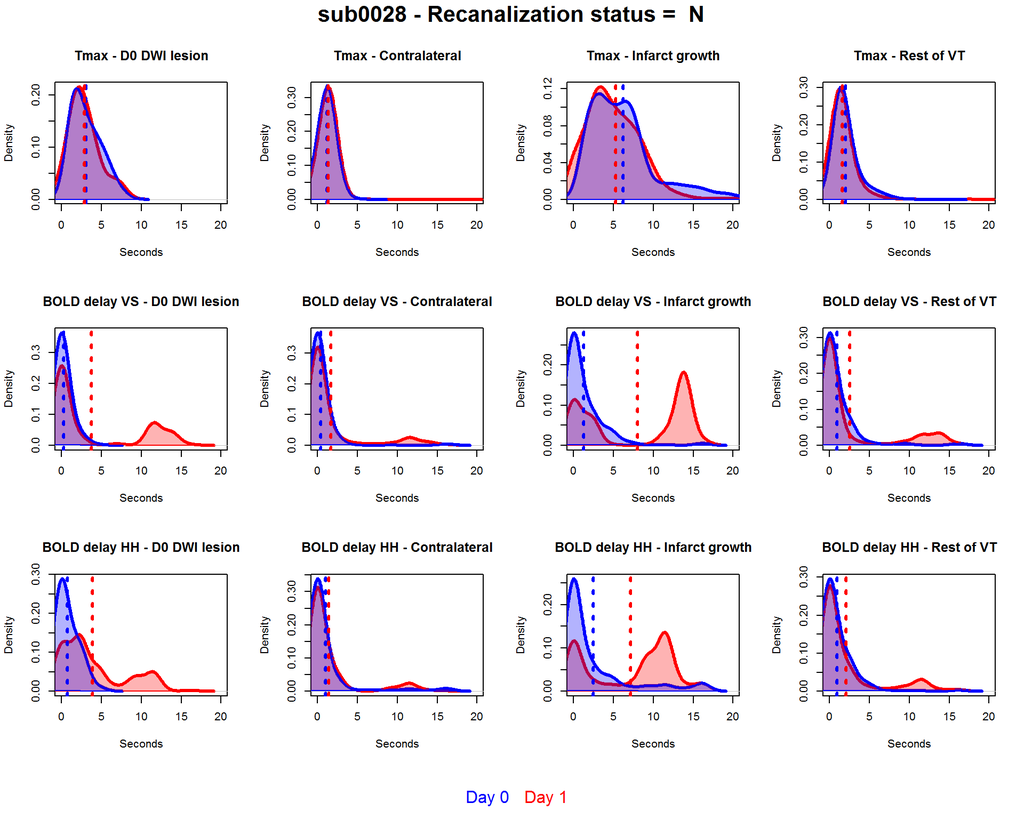

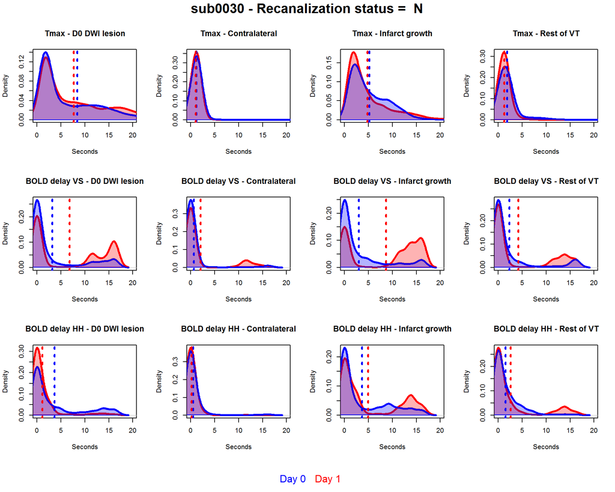

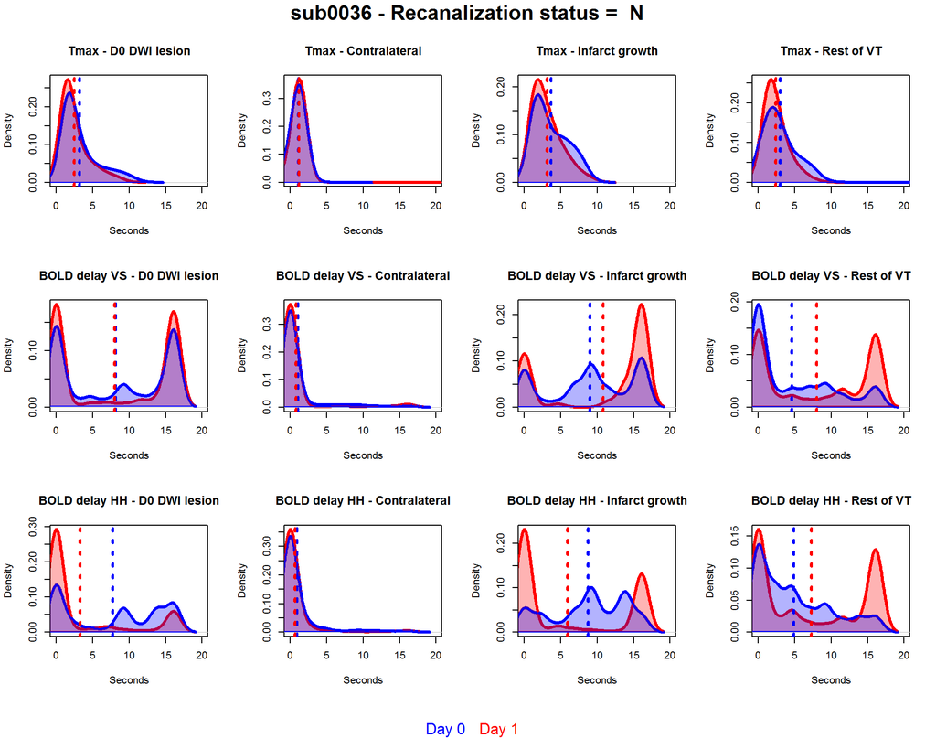

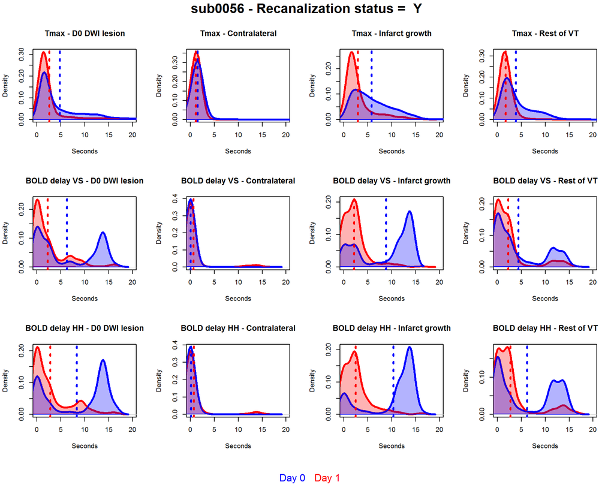

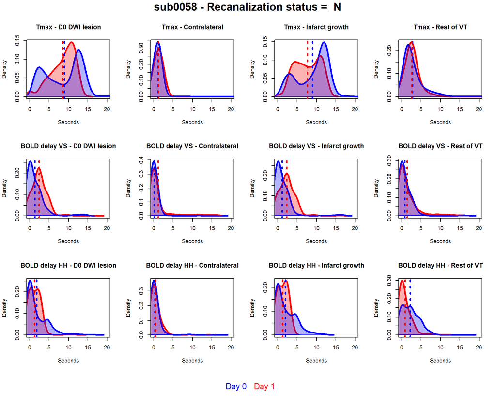

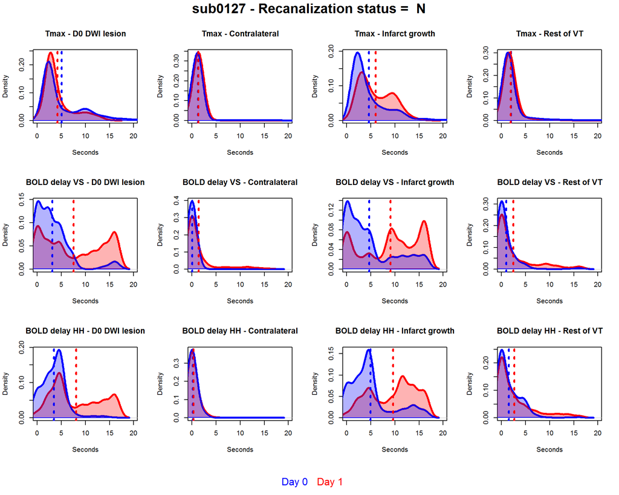

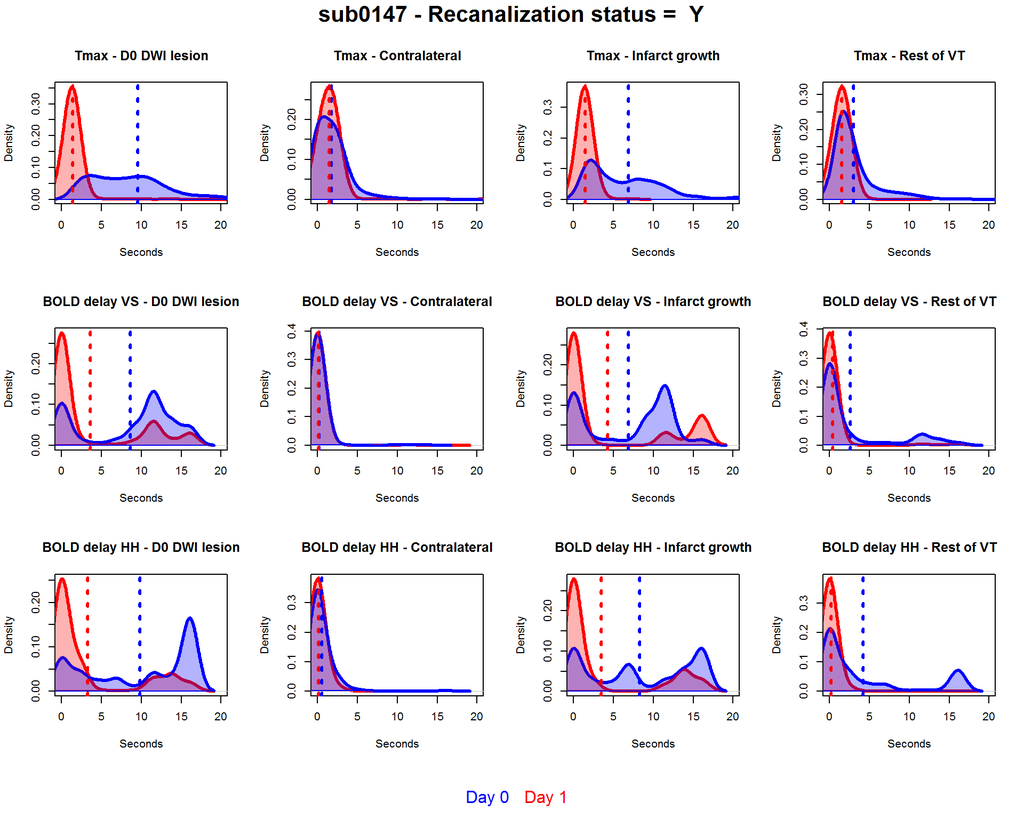

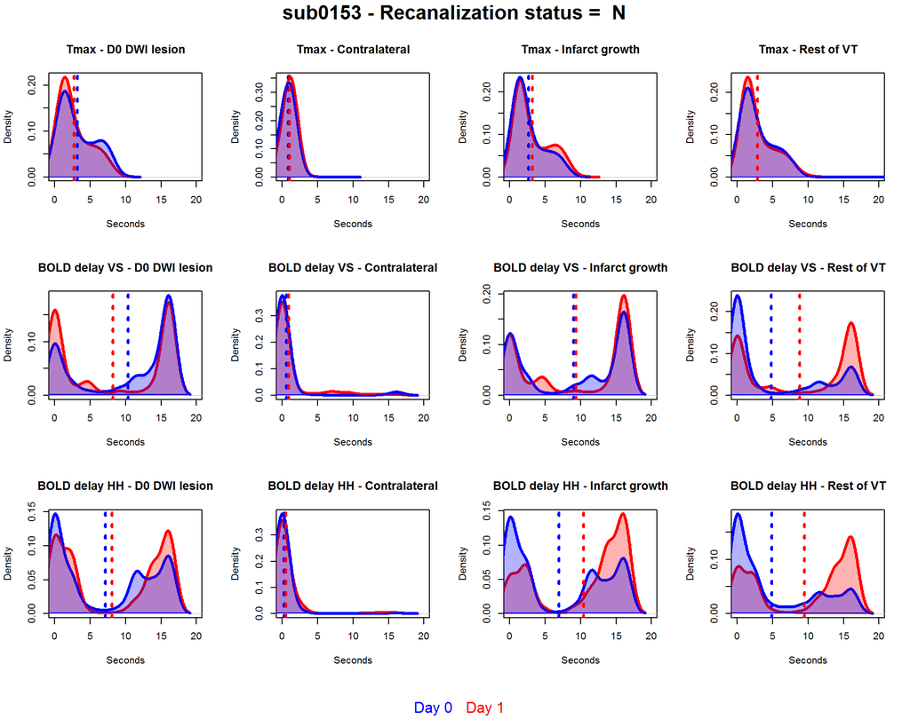

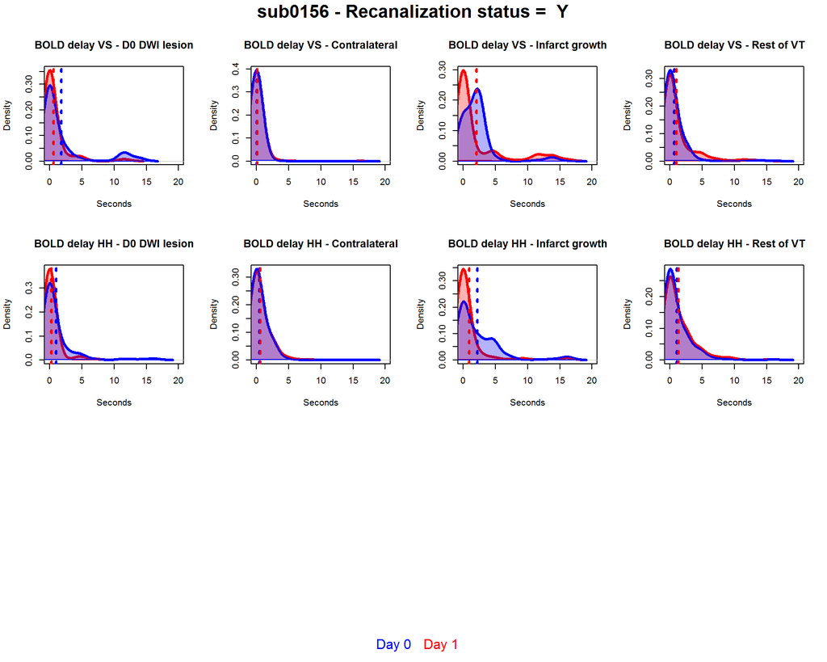

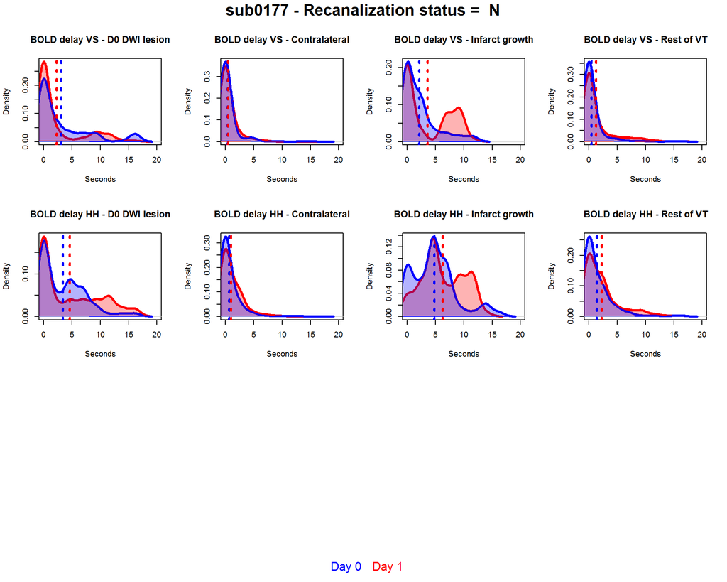

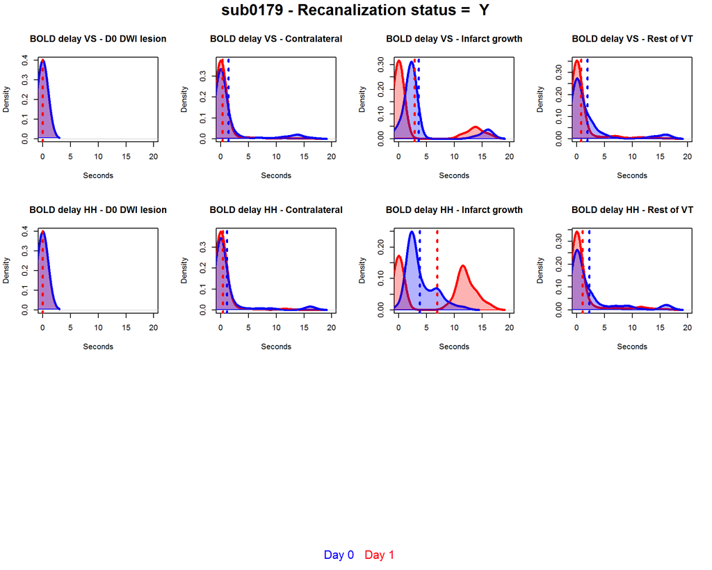

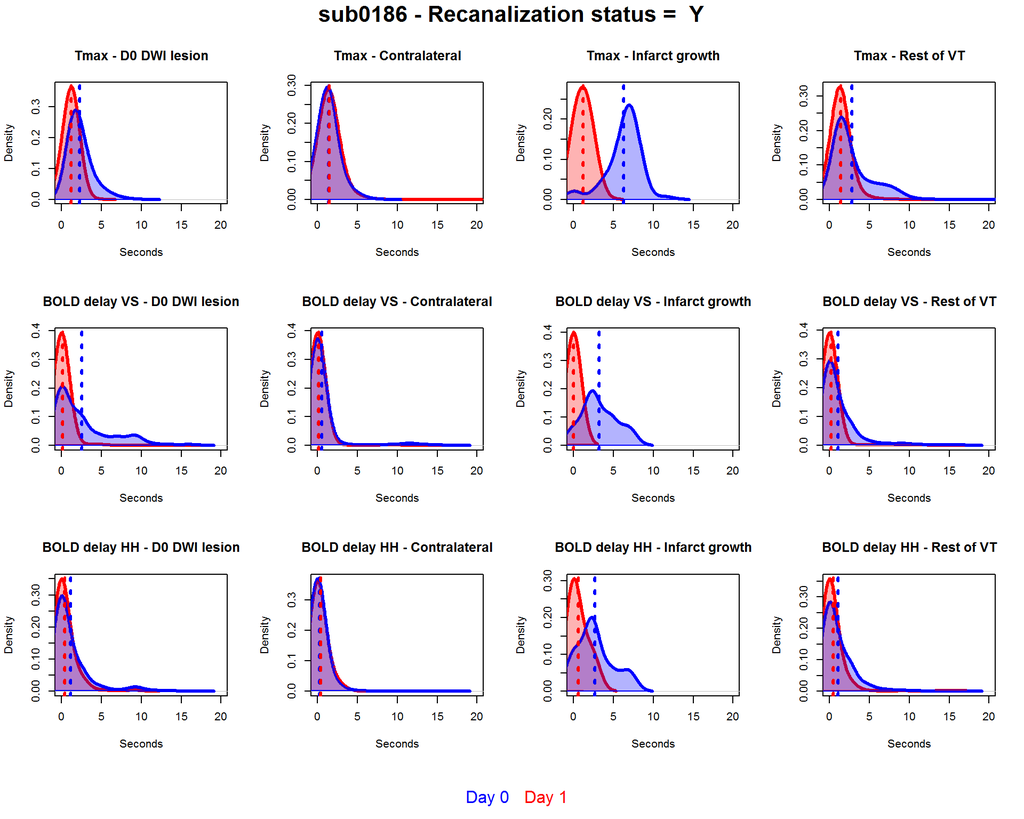

[3 more figures not shown]